# Regressão Romântica

Dandara Sousa

O *speed dating* é um modelo de encontros muito conhecido nos Estados Unidos. Nele, um grande grupo se divide em pares onde cada par tem 4 minutos para se conhecer. Após o término desse tempo os pares são rotacionados e tudo se repete. A ideia é que no final alguns casais se formem e passem para um encontro mais demorado (e sem competições). Parece ser tudo simples, não é mesmo? O que poderia dar errado?

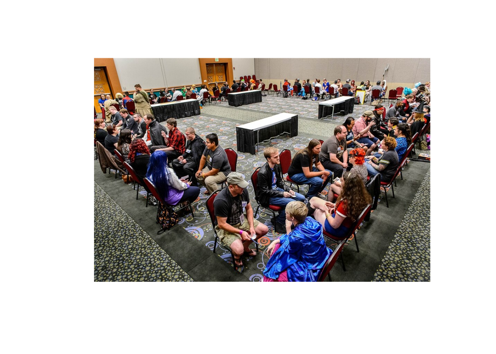

```r
dating.img <- image_read("https://www.sltrib.com/resizer/IKzaM8Tui0iSyZXA07IGqGzDr6o=/970x0/filters:quality(100)/arc-anglerfish-arc2-prod-sltrib.s3.amazonaws.com/public/ZSSRJZWRQJETDMOJEDQEOQM2OI.jpg", "50")
plot(as.raster(dating.img))
```

### Prazer, Speed Dating

Nesse relatório temos dados de quase 5000 desses encontros coletados pelos professores da Columbia Business School. Os participantes tinham vários encontros de 4 minutos por noite. Após cada um, preenchiam fichas avaliando aqueles com quem se encontraram. Cada linha nos dados representa um desses encontros.

```r
speeddating <- read_csv("../data/speed-dating2.csv") %>%
  mutate(dec = as.factor(dec),
         gender = as.factor(gender))
```

Em resumo, nossas *colunas* são:

- iid : id do participante p1 no encontro
- gender : sexo do p1, 0 = mulher
- order : dos vários encontros realizados em uma noite, esse foi o n-ésimo, segundo essa variável
- pid : id do participante p2
- int_corr : correlação entre os interesses de p1 e p2
- samerace : p1 e p2 são da mesma raça?
- age_o : idade de p2
- age : idade de p1
- field : campo de estudo de p1
- race : raça de p1. O código é Black/African American=1; European/Caucasian-American=2; Latino/Hispanic American=3; Asian/Pacific Islander/Asian-American=4; Native American=5; Other=6
- from : de onde p1 é
- career : que carreira p1 quer seguir
- sports, tvsports, exercise, dining, museums, art, hiking, gaming, clubbing, reading, tv, theater, movies, concerts, music, shopping, yoga : De 1 a 10, quão interessado p1 é em cada uma dessas atividades.
- attr : quão atraente p1 achou p2
- sinc : quão sincero p1 achou p2
- intel : quão inteligente p1 achou p2
- fun : quão divertido p1 achou p2
- amb : quão ambicioso p1 achou p2
- shar : quanto p1 achou que compartilha interesses e hobbies com p2
- like : no geral, quanto p1 gostou de p2?
- prob : que probabiliade p1 acha que p2 tem de querer se encontrar novamente com p- (escala 1-10)
- attr3_s : quanto p1 acha que é atraente
- sinc3_s : quanto p1 acha que é sincero
- intel3_s : quanto p1 acha que é inteligente
- fun3_s : quanto p1 acha que é divertido
- amb3_s : quanto p1 acha que é ambicioso
- dec: se houve um match

### Ah! Me fala sobre você…

Num passeio rápido vamos conhecer melhor o que temos. Primeiro, sobre o gênero dos participantes:

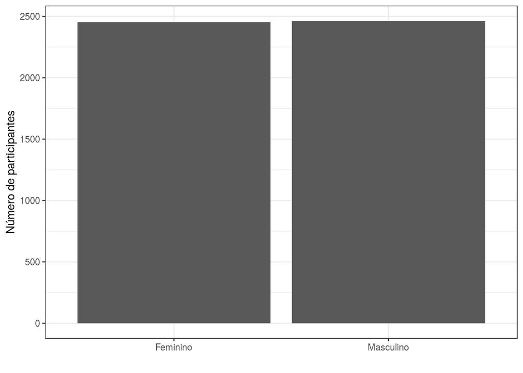

```r
speeddating %>%
  group_by(gender) %>%
  summarise(n = n()) %>%
  ggplot(aes(x = gender, y = n)) +
  geom_bar(stat = "identity") +
  labs(x = "", y = "Número de participantes") +
  scale_x_discrete(labels = c('Feminino', 'Masculino'))
```

Depois a idade:

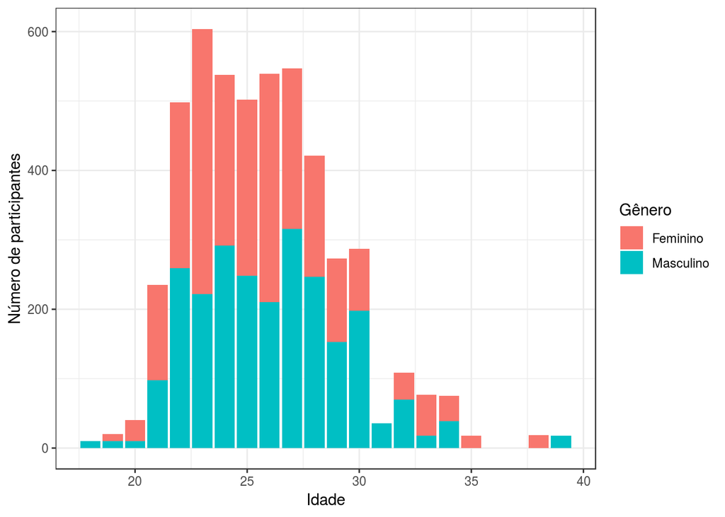

```r
speeddating %>%
  group_by(gender, age) %>%
  summarise(n = n()) %>%
  ggplot(aes(x = age, y = n, fill = gender)) +
  geom_bar(stat = "identity") +
  labs(x = "Idade", y = "Número de participantes", fill = "Gênero") +
  scale_fill_discrete(labels = c('Feminino', 'Masculino'))
```

E por último a raça:

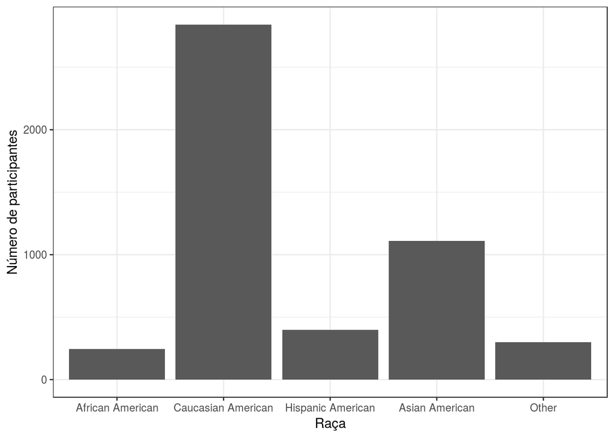

```r
speeddating %>%
  group_by(race) %>%
  summarise(n = n()) %>%
  na.omit() %>%
  ggplot(aes(x = as.factor(race), y = n)) +
  geom_bar(stat = "identity") +
  labs(x = "Raça", y = "Número de participantes") +
  scale_x_discrete(labels = c('1' = 'African American', '2' = 'Caucasian American','3' ='Hispanic American','4' = 'Asian American','5' ='Native American', '6' = 'Other'))
```

Então, em maioria nossos dados falam sobre pessoas caucasianas e jovens. Seria esse o perfil das pessoas criteriosas demais para achar alguém de forma fácil ou de alguém sem paciência para procurar pessoas?

### Será que é ele não?

Estamos todos curiosos pra saber a fórmula do sucesso (aka modelo do match) e vamos colocar aqui nosso dedo na história. Após olhar os dados os atributos foram escolhidos e seus repectivos motivos são:

- **order**: será que os últimos serão os primeiros (a conseguir um date)?
- **attr**: achar uma pessoa atraente é motivo forte para eu desejar ter um encontro depois?
- **intel**: será que os nerds são fortes bons partidos?
- **fun**: aquela velha história de que se você fizer alguém rir, você já tá mais perto de conquistá-la…

Observando na correlação o que nos interessa mesmo é a relação dos atributos com o `dec`que é o resultado final.

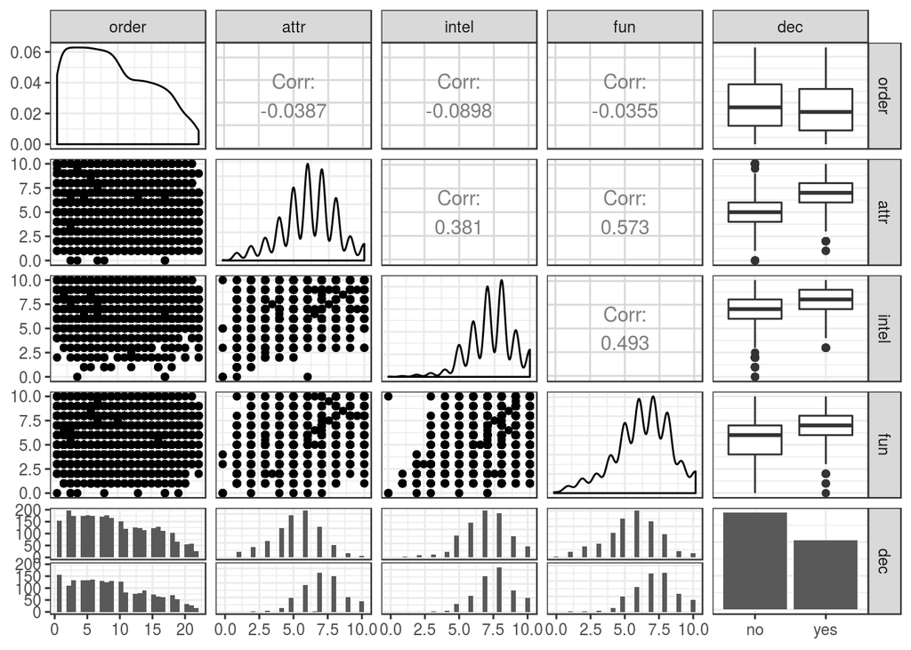

```r
speeddating.resume <- speeddating %>%
  select(order, attr, intel, fun, dec)
ggpairs(speeddating.resume)
```

Para o modelo do match (estatísticamente falando é o modelo de regressão) utilizaremos o modelo de regressão logística.

```r
speeddating.model = glm(dec ~order + attr + intel + fun,
                        data = speeddating.resume,
                        family = "binomial")
```

### Partindo pro juntos e shallow now

Modelo pronto, queremos saber quais dos atributos têm efeito expressivo na chance de ocorrer match? E como é esse efeito?

```r
tidy(speeddating.model, conf.int = TRUE, exponentiate = TRUE, conf.level = .95)
```

```
## # A tibble: 5 x 7
##   term        estimate std.error statistic   p.value conf.low conf.high
##   <chr>          <dbl>     <dbl>     <dbl>     <dbl>    <dbl>     <dbl>
## 1 (Intercept)  0.00528   0.231     -22.7   3.33e-114  0.00334   0.00825
## 2 order        0.994     0.00620    -0.902 3.67e-  1  0.982     1.01
## 3 attr         1.75      0.0255     22.0   1.55e-107  1.67      1.85
## 4 intel        0.915     0.0281     -3.17  1.54e-  3  0.866     0.967
## 5 fun          1.39      0.0250     13.1   3.23e- 39  1.32      1.46
```

Para os atributos escolhidos, a ordem da pessoa no encontro não teve um efeito expressivo. Na verdade, pelo intervalo de confiança de 95% a ordem pode está entre 0,9824 e 1,0065, sendo um efeito pequeno e negativo ou irrisório. Semelhante acontece com a inteligência que com IC de 95% está entre 0,8655 e 0,9665, o efeito pode ser considerado mínimo e negativo. Os atributos que se destacaram foram o senso de humor, que chega a acrescentar até 0,4584 na fórmula do match (o valor estimado é de 1,3881 com IC de 95%[1,322, 1,4584]) e a aparência que neste modelo é o que mais importa com estimativa de 1,7543 e IC de 95%[1,6696, 1,8453].

Ou seja, ser bonito e engraçado conta mais que ser inteligente e o primeiro da fila. Mas ainda há esperanças para todos!

```r
pR2(speeddating.model)
```

```
##           llh       llhNull            G2      McFadden          r2ML
## -2464.6051992 -3338.8632511  1748.5161039     0.2618430     0.3118678
##          r2CU
##     0.4103059
```

Avaliando o modelo com o R<sup>2</sup> de McFadden vemos que tudo que fizemos até agora explica apenas 26% dos nossos dados. Para quem se encaixa nos atributos, essa análise dá uma força na autoestima mas também temos boas notícias para os que não se sentiram agraciados.